# Course Project of Pratical ML

Jiuyuan

July 21, 2019

## BACKGROUND

This is an R Markdown document for the course project of Pratical ML. Training and Testing dataset are given. The training data is shown as below.

```r
pml.training <- read.csv("~/Documents/Practical_ML/CourseProject/pml-training.csv")
```

## PROJECT GOAL

Predict the manner in which they did the exercise. The variable to be predicted is “classe” (Col. 160) in the data. Any combination of the other variables could be used.

## PART 0 - DATA CLEANING AND PARTITION

Since there are a lot of meaningless data in the given training set, to make it eaiser in the following steps, a data cleaning is performed as below. All columns with NA or #DIV/0! are removed.

```r
pml.training[pml.training == "#DIV/0!"] <- NA
pml.training <- pml.training[, colSums(is.na(pml.training)) == 0]
dim.data.frame(pml.training)
```

```
## [1] 19622    60
```

60 variables are left for our analysis in the following steps.

There are also some variables that are not numerics left which may trouble our numeric analysis later. So, there columns are moved to the very end of the data.

```r
pml.training.factors <- pml.training[, unlist(lapply(pml.training, is.factor))]
pml.training.numerics <- pml.training[, unlist(lapply(pml.training, is.numeric))]
pml.training<- cbind(pml.training.numerics, pml.training.factors)
```

Then split the cleaned data into training sets and varification sets.

```r
library(ggplot2)
library(lattice)
library(caret)
set.seed(1414)
inTrain <- createDataPartition(pml.training$classe, p = 3/4)[[1]];
training <- pml.training[inTrain,]
verifying <- pml.training[-inTrain,]
```

## PART 1 - DATA PREPROCESS

#### 1.1 Understand Correlations

It is almost imposible to know the physical meaning of all the descripters, but it is possible to find correlation from the data.

```r
checkCor <- cor(training[, unlist(lapply(training, is.numeric))])
findCorrelation(checkCor, cutoff = 0.95)
```

```
## [1] 14  5 12
```

```r
findCorrelation(checkCor, cutoff = 0.75)
```

```
##  [1] 14  5 26 13  8 40 12  6 41 39 42 43 38 25 27 29 16 52 22
```

We see that there are some descripters are highly related to each other. a training set with reduced correlation is prepared.

```r
highlyCorDes <- findCorrelation(checkCor, cutoff = 0.95)
training2 <- training[,-highlyCorDes]
```

#### 1.2 PCA

60 is still a relatively large number to perform ML models directly. So, firstly, a preprocess using Principle Components Analysis is performed on numeric variables in “training”.

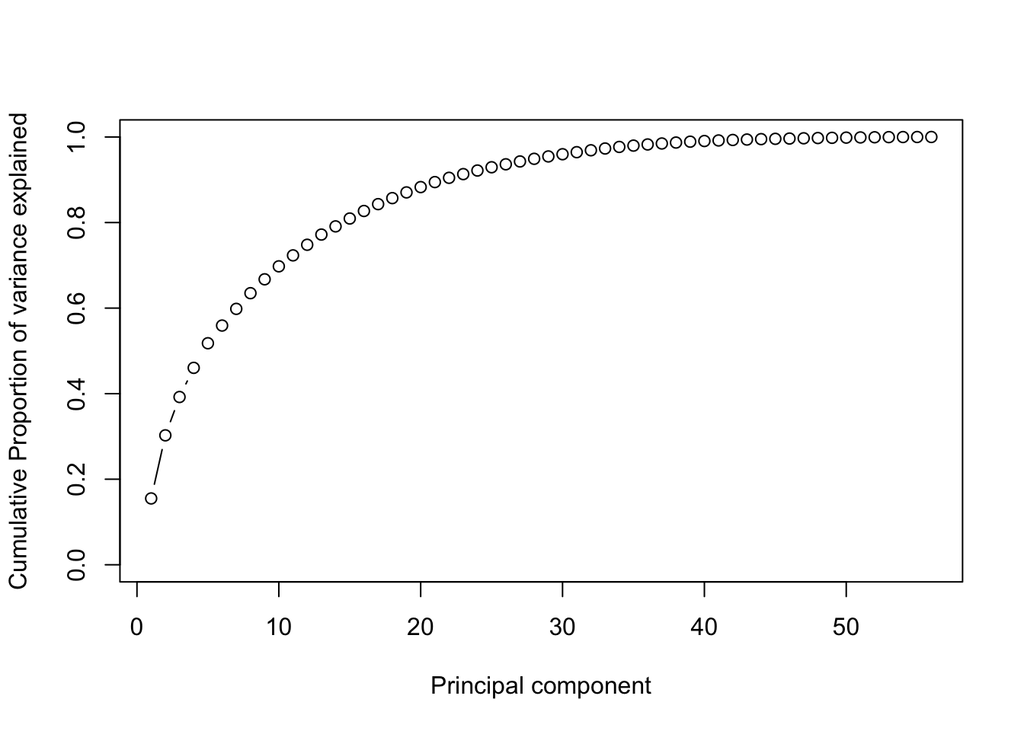

```r
checkPCA <- prcomp(training[, unlist(lapply(training, is.numeric))], scale = TRUE)
chartPCA <- summary(checkPCA)$importance
plot(chartPCA[3,], xlab="Principal component",
                   ylab="Cumulative Proportion of variance explained",
                   ylim=c(0,1), type='b')
```

The plot shown above indicates that if using a threshold of 0.95, we will leave 29 principle components for next steps. This cuts the variable pool to half (using “training”). We can do PCA similarly for less correlated training set (“training2”):

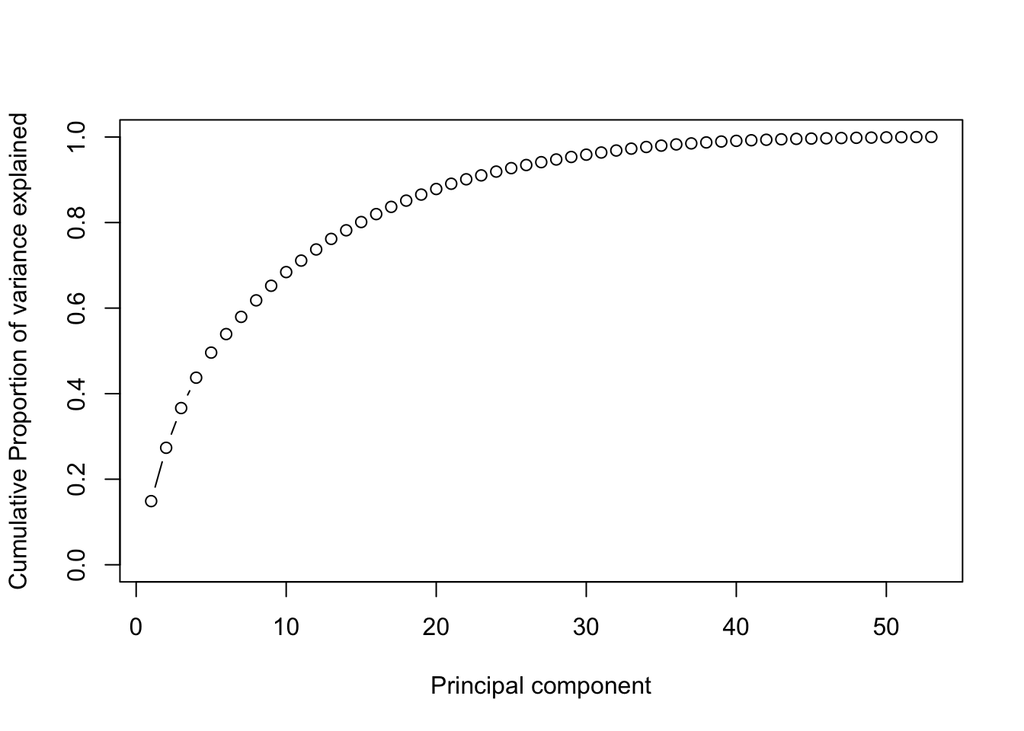

```r
checkPCA2 <- prcomp(training2[, unlist(lapply(training2, is.numeric))], scale = TRUE)
chartPCA2 <- summary(checkPCA2)$importance
plot(chartPCA2[3,], xlab="Principal component",
                   ylab="Cumulative Proportion of variance explained",
                   ylim=c(0,1), type='b')
```

The result is slitely different than above. Effect of using PCA or not will be check in PART 2.

## PART 2 - TRAINING

Following the bootstrap resampling from PART 0, two training methods were used and compared in this part.

#### 2.1 Random Forest

```r
set.seed(858)
rfFit1 <- train(classe ~., data = training, method = "rf")
rfFit1
```

```
## Random Forest
##
## 14718 samples
##    59 predictor
##     5 classes: 'A', 'B', 'C', 'D', 'E'
##
## No pre-processing
## Resampling: Bootstrapped (25 reps)
## Summary of sample sizes: 14718, 14718, 14718, 14718, 14718, 14718, ...
## Resampling results across tuning parameters:
##
##   mtry  Accuracy   Kappa
##    2    0.9937736  0.9921271
##   41    0.9998594  0.9998221
##   81    0.9998299  0.9997848
##
## Accuracy was used to select the optimal model using the largest value.
## The final value used for the model was mtry = 41.
```

```r
rfFit2 <- train(classe ~., data = training, preProcess = "pca", method = "rf")
```

[output not shown]

[output cut: 94 more lines]

[output not shown]

```r
rfFit2
```

```
## Random Forest
##
## 14718 samples
##    59 predictor
##     5 classes: 'A', 'B', 'C', 'D', 'E'
##
## Pre-processing: principal component signal extraction (81), centered
##  (81), scaled (81)
## Resampling: Bootstrapped (25 reps)
## Summary of sample sizes: 14718, 14718, 14718, 14718, 14718, 14718, ...
## Resampling results across tuning parameters:
##
##   mtry  Accuracy   Kappa
##    2    0.9799512  0.9746413
##   41    0.9645060  0.9551045
##   81    0.9642155  0.9547366
##
## Accuracy was used to select the optimal model using the largest value.
## The final value used for the model was mtry = 2.
```

Using the “verifying” set to check the performance of the two fits:

```r
rfPredict1 <- predict(rfFit1, newdata = verifying)
confusionMatrix(rfPredict1, verifying$classe)$table
```

```
##           Reference
## Prediction    A    B    C    D    E
##          A 1395    0    0    0    0
##          B    0  949    0    0    0
##          C    0    0  855    0    0
##          D    0    0    0  804    0
##          E    0    0    0    0  901
```

```r
confusionMatrix(rfPredict1, verifying$classe)$overall
```

```
##       Accuracy          Kappa  AccuracyLower  AccuracyUpper   AccuracyNull
##      1.0000000      1.0000000      0.9992481      1.0000000      0.2844617
## AccuracyPValue  McnemarPValue
##      0.0000000            NaN
```

Random Forest without preprocess gives a 100% accuracy. Most likely, this model is over fitted.

```r
rfPredict2 <- predict(rfFit2, newdata = verifying)
confusionMatrix(rfPredict2, verifying$classe)$table
```

```
##           Reference
## Prediction    A    B    C    D    E
##          A 1388    3    0    0    0
##          B    3  939   17    0    0
##          C    3    7  834   16    0
##          D    0    0    4  788    5
##          E    1    0    0    0  896
```

```r
confusionMatrix(rfPredict2, verifying$classe)$overall
```

```
##       Accuracy          Kappa  AccuracyLower  AccuracyUpper   AccuracyNull
##      0.9879690      0.9847833      0.9845080      0.9908292      0.2844617
## AccuracyPValue  McnemarPValue
##      0.0000000            NaN
```

#### 2.2 Support Vector Machines

```r
svmFit1 <- train(classe ~., data = training, method = "svmLinear3")
svmFit2 <- train(classe ~., data = training, method = "svmLinear3", preProcess = "pca")
```

Using the “verifying” set to check the performance of the two fits:

```r
svmPredict1 <- predict(svmFit1, newdata = verifying)
confusionMatrix(svmPredict1, verifying$classe)$table
```

```
##           Reference
## Prediction    A    B    C    D    E
##          A 1395  949  855  804  901
##          B    0    0    0    0    0
##          C    0    0    0    0    0
##          D    0    0    0    0    0
##          E    0    0    0    0    0
```

```r
confusionMatrix(svmPredict1, verifying$classe)$overall
```

```
##       Accuracy          Kappa  AccuracyLower  AccuracyUpper   AccuracyNull
##      0.2844617      0.0000000      0.2718640      0.2973164      0.2844617
## AccuracyPValue  McnemarPValue
##      0.5054062            NaN
```

```r
svmPredict2 <- predict(svmFit2, newdata = verifying)
confusionMatrix(svmPredict2, verifying$classe)$table
```

```
##           Reference
## Prediction    A    B    C    D    E
##          A 1389   17    0    0    0
##          B    5  742   60   30    0
##          C    0  186  745  131    0
##          D    0    4   50  632    7
##          E    1    0    0   11  894
```

```r
confusionMatrix(svmPredict2, verifying$classe)$overall
```

```
##       Accuracy          Kappa  AccuracyLower  AccuracyUpper   AccuracyNull
##      0.8976346      0.8705132      0.8888105      0.9059820      0.2844617
## AccuracyPValue  McnemarPValue
##      0.0000000            NaN
```

#### 2.3 Combining Predictors

An overview of rfPredict2 and svmPredict2:

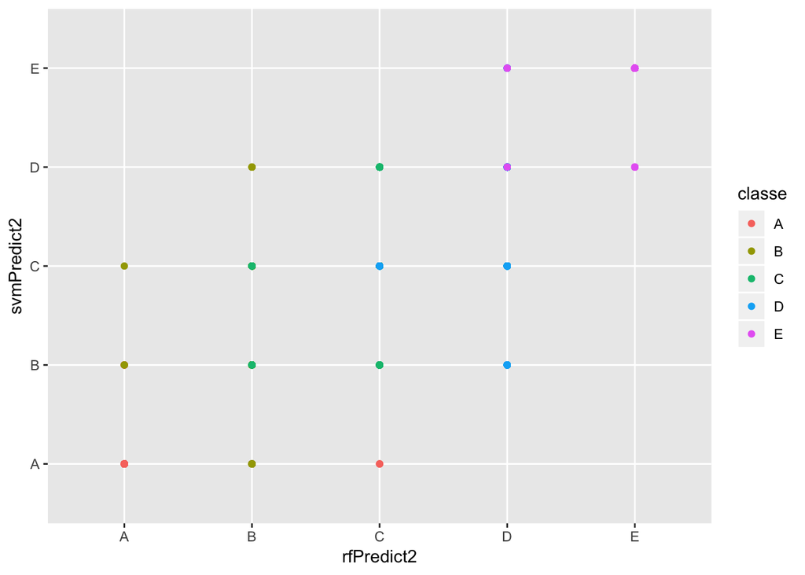

```r
qplot(rfPredict2, svmPredict2, color = classe, data = verifying)
```

The plot shows the consistence of the two predictions, as well as their errors by looking at the color of the dots. Predictions on level A and E are generally more consitant than B, C, or D for the two models.

1. A LogitBoost method is used for prediction based on a combination of rfPredict2 and svmPredict2:

```r
predDF <- data.frame(rfPredict2, svmPredict2, classe = verifying$classe)
comboFit <- train(classe ~., data = predDF, method = "LogitBoost")
comboPredict <- predict(comboFit, predDF)
confusionMatrix(comboPredict, predDF$classe)$table
```

```
##           Reference
## Prediction    A    B    C    D    E
##          A 1388    3    0    0    0
##          B    0  922   17    0    0
##          C    0    7  834   16    0
##          D    0    0    4  788    5
##          E    1    0    0    0  896
```

```r
confusionMatrix(comboPredict, predDF$classe)$overall
```

```
##       Accuracy          Kappa  AccuracyLower  AccuracyUpper   AccuracyNull
##      0.9891416      0.9862654      0.9858207      0.9918560      0.2845728
## AccuracyPValue  McnemarPValue
##      0.0000000            NaN
```

2. Another random forest is used for prediciton based on a combination of rfPredict2 and svmPredict2.

```r
comboFit2 <- train(classe ~., data = predDF, method = "rf")
comboPredict2 <- predict(comboFit2, predDF)
confusionMatrix(comboPredict2, predDF$classe)$table
```

```
##           Reference
## Prediction    A    B    C    D    E
##          A 1391    2    0    0    0
##          B    3  940   17    0    0
##          C    0    7  834   16    0
##          D    0    0    4  788    5
##          E    1    0    0    0  896
```

```r
confusionMatrix(comboPredict2, predDF$classe)$overall
```

```
##       Accuracy          Kappa  AccuracyLower  AccuracyUpper   AccuracyNull
##      0.9887847      0.9858141      0.9854264      0.9915402      0.2844617
## AccuracyPValue  McnemarPValue
##      0.0000000            NaN
```

## PART 3 - PREDICTION

In this part, pml.testing was loaded to predict the performance of the participants using the models trained in PRT 2.

Cleaning of the data set:

```r
pml.testing <- read.csv("~/Documents/Practical_ML/CourseProject/pml-testing.csv")
pml.testing[pml.testing == "#DIV/0!"] <- NA
pml.testing <- pml.testing[, colSums(is.na(pml.testing)) == 0]

pml.testing.factors <- pml.testing[, unlist(lapply(pml.testing, is.factor))]
pml.testing.numerics <- pml.testing[, unlist(lapply(pml.testing, is.numeric))]
pml.testing<- cbind(pml.testing.numerics, pml.testing.factors)

dim.data.frame(pml.testing)
```

```
## [1] 20 60
```

Do the final predictions using rfFit2, svmFit2, and then ComboFit and ComboFit2:

```r
finalPredict.rf <- predict(rfFit2, pml.testing)
finalPredict.svm <- predict(svmFit2, pml.testing)
finalPredictDF <- data.frame(rfPredict2 = finalPredict.rf, svmPredict2 = finalPredict.svm)
finalPredict.combo <- predict(comboFit, finalPredictDF)
finalPredict.combo2 <- predict(comboFit2, finalPredictDF)
```

```r
finalPredict.rf
```

```
##  [1] B A A A A E D B A A B C B A E E A B B B
## Levels: A B C D E
```

```r
finalPredict.svm
```

```
##  [1] A A A A A D D A A A A A A A D B A A A A
## Levels: A B C D E
```

```r
finalPredict.combo
```

```
##  [1] <NA> A    A    A    A    E    D    <NA> A    A    <NA> <NA> <NA> A
## [15] E    E    A    <NA> <NA> <NA>
## Levels: A B C D E
```

```r
finalPredict.combo2
```

```
##  [1] B A A A A E D B A A B A B A E E A B B B
## Levels: A B C D E
```

The comboFit trained using logitBoost is having trouble predicting all the B levels of the performance. Currently not sure about what happened. Result of Combo2 is used for the quiz.